## Task 1

```r
  getwd()
```

```
## [1] "C:/Users/Adrienne/Dropbox/R/lab4"
```

## Task 2

```r
  tail(spruce)
```

```
## # A tibble: 6 x 2
##   BHDiameter Height
##        <dbl>  <dbl>
## 1       17.7   19.9
## 2       20.7   19.4
## 3       21     20.4
## 4       13.3   15.5
## 5       15.9   17.6
## 6       22.9   19.2
```

## Task 3

```r
  spruce%T>%trendscatter(x=.$Height,y=.$BHDiameter,f=0.5)%>%lm()->spruce.lm
```

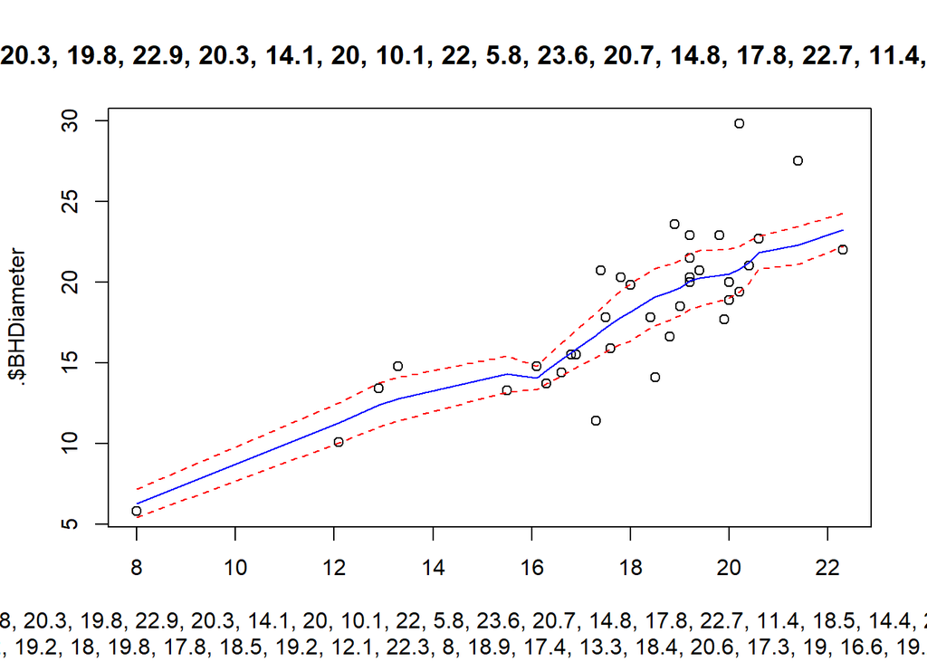

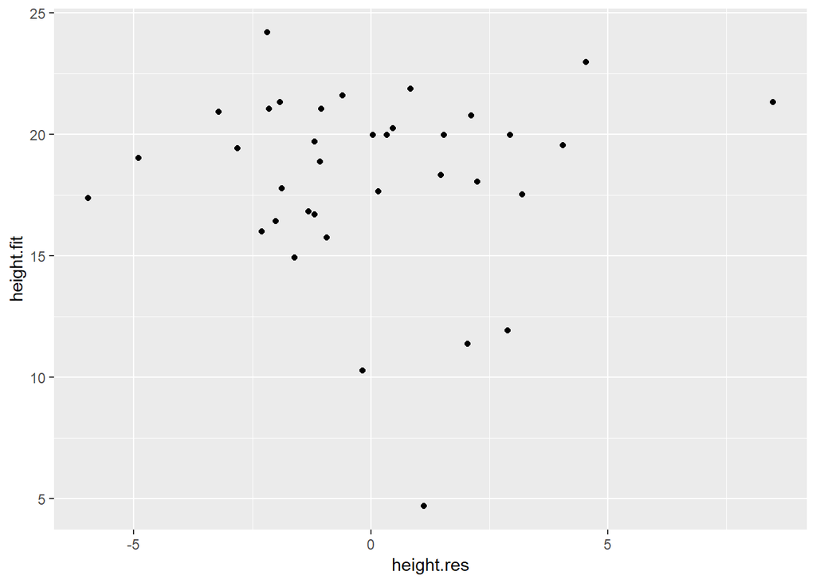

```r
  spruce.lm%T>%{residuals(.)->>height.res}%>%fitted->height.fit
  qplot(x=height.res,y=height.fit)
```

```r
  trendscatter(x=height.res,y=height.fit)
```

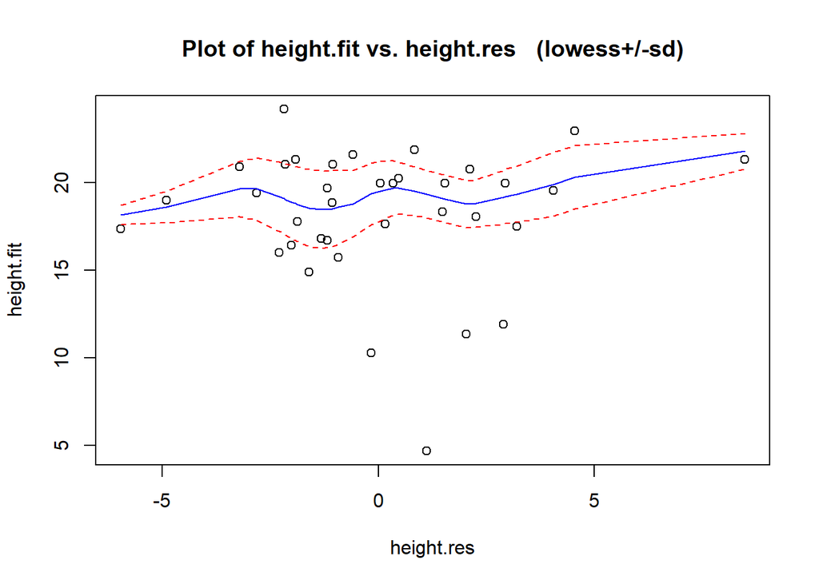

There is little pattern in the residuals vs fit plot

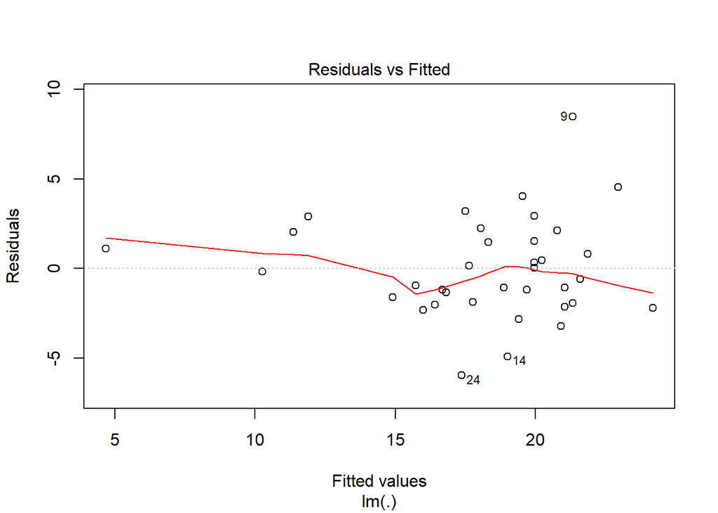

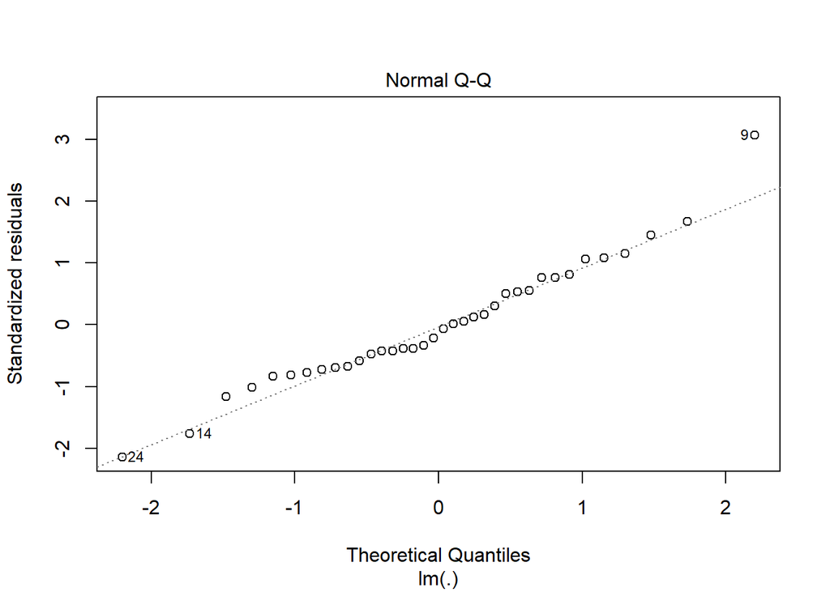

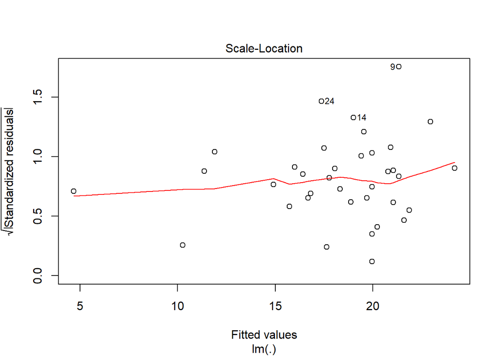

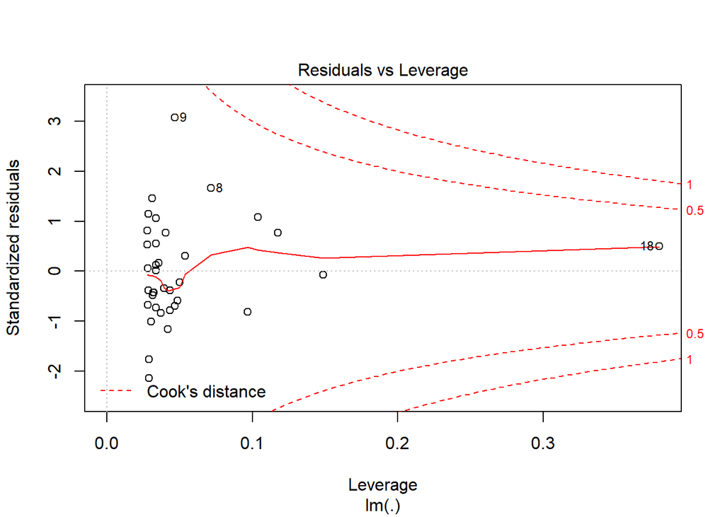

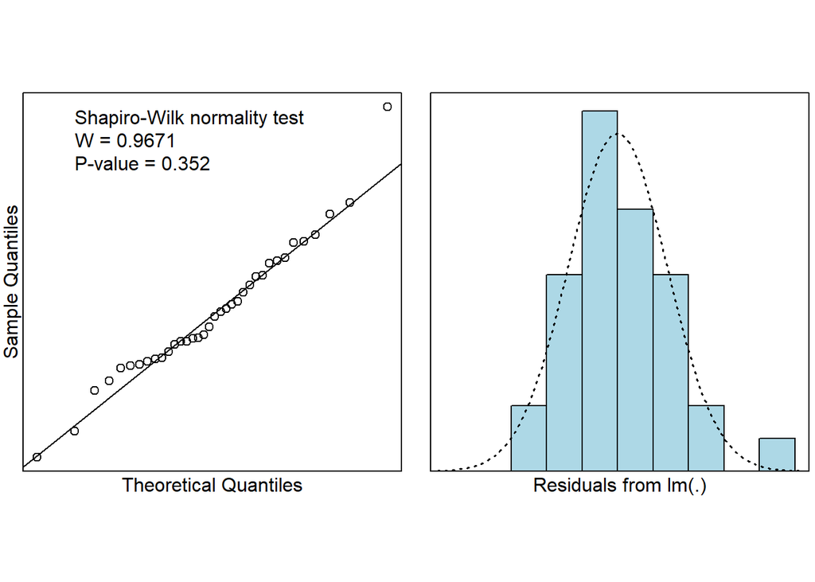

```r
  spruce.lm%T>%plot%>%normcheck(,shapiro.wilk=TRUE)
```

```r
  summary(spruce.lm)
```

```
##
## Call:
## lm(formula = .)
##
## Residuals:
##     Min      1Q  Median      3Q     Max
## -5.9672 -1.8884 -0.3846  1.6644  8.4761
##
## Coefficients:
##             Estimate Std. Error t value Pr(>|t|)
## (Intercept)  -6.2366     3.0647  -2.035   0.0497 *
## Height        1.3644     0.1691   8.069 2.09e-09 ***
## ---
## Signif. codes:  0 '***' 0.001 '**' 0.01 '*' 0.05 '.' 0.1 ' ' 1
##
## Residual standard error: 2.824 on 34 degrees of freedom
## Multiple R-squared:  0.6569, Adjusted R-squared:  0.6468
## F-statistic:  65.1 on 1 and 34 DF,  p-value: 2.089e-09
```

The P-value is big, so the null-hypothesis is accepted (in this case, that the residuals are normally distributed around 0.) Given this, and assuming that the shapes of spruces aren’t affected by measurement, we can conclude that there is a correlation between the height and diameter. The r-squared of the model is low though, so we can’t use the simple regression linear model to make predictions of one value given the other.

## Task 4

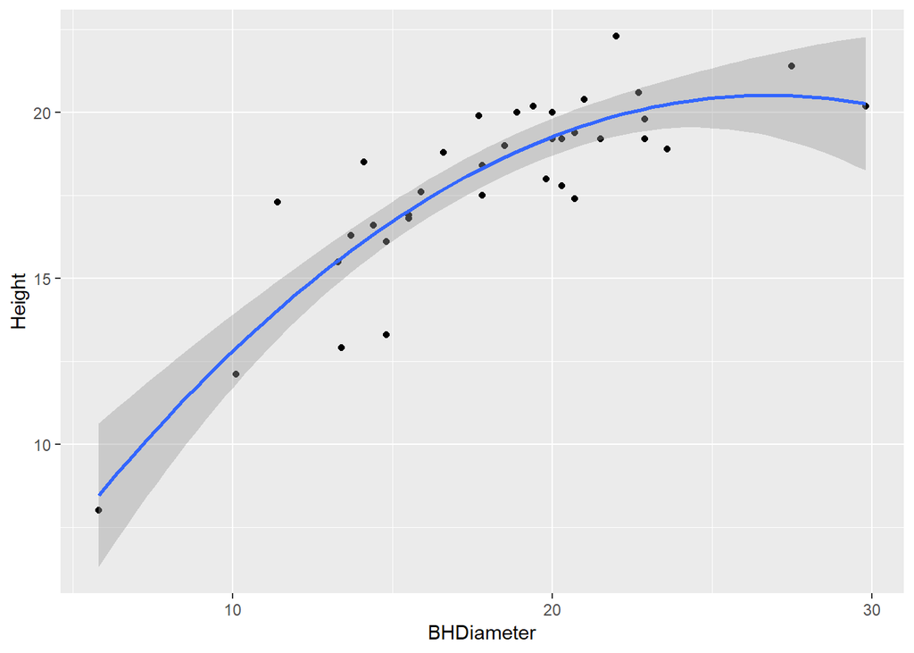

```r
  quad.lm<-lm(BHDiameter~Height + I(BHDiameter^2),data=spruce)
  quad.lm%T>%{residuals(.)->>quad.res}%>%fitted->quad.fit
  ggplot(spruce,aes(y = Height,x=BHDiameter))+
      geom_point() +
      stat_smooth(method=lm, formula = y ~ x + I(x^2))
```

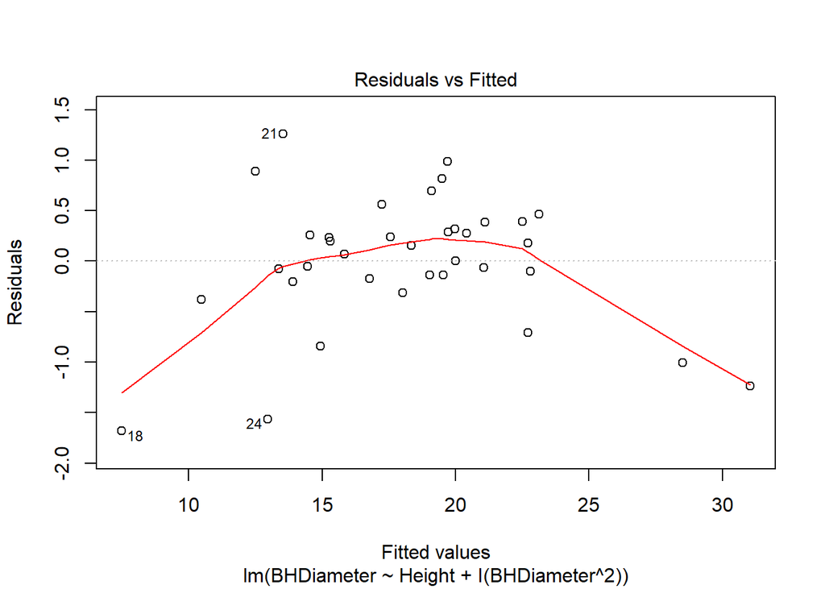

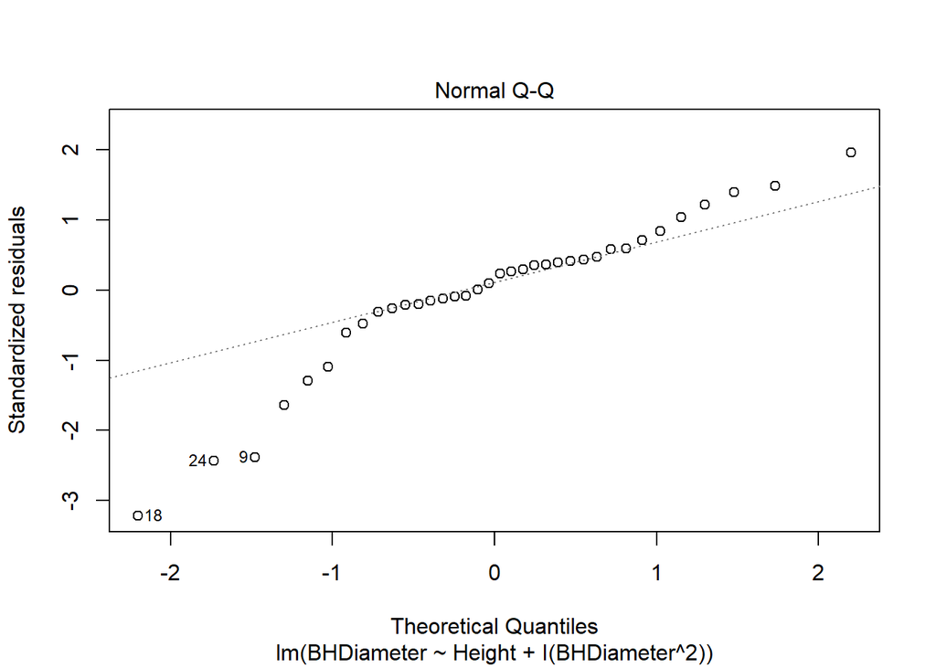

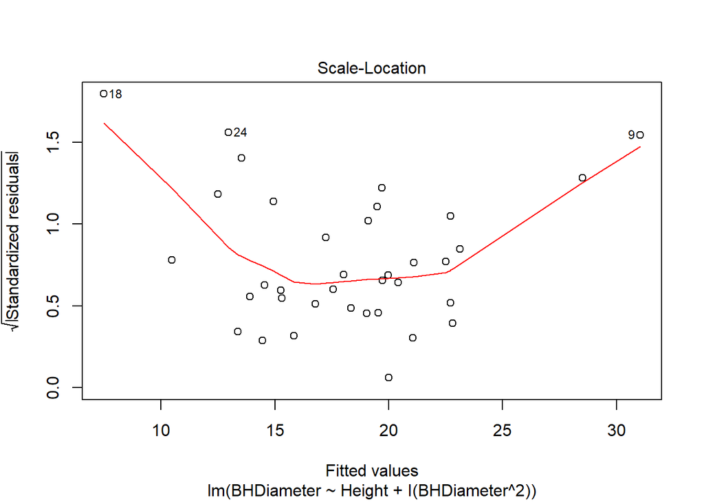

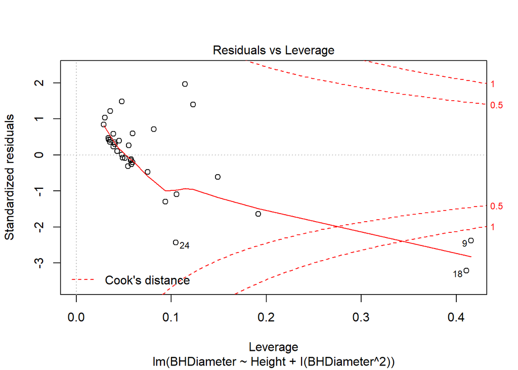

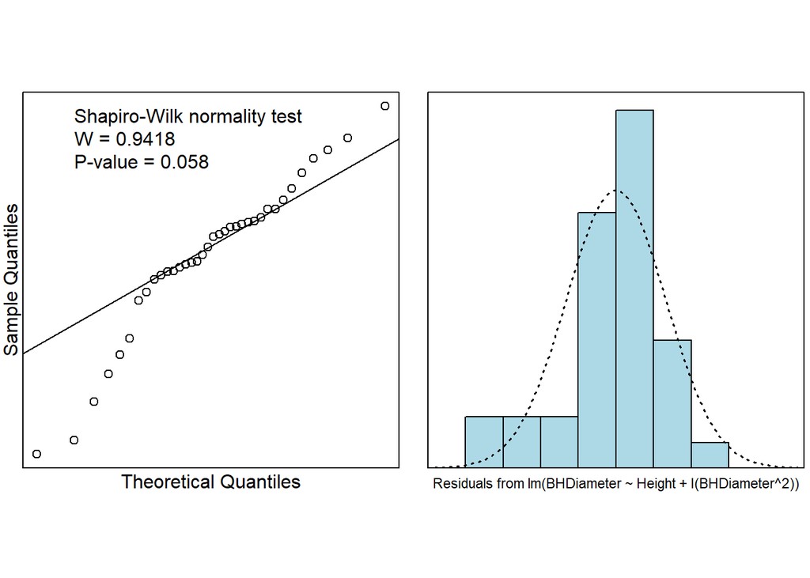

```r
  quad.lm%T>%plot%>%normcheck(,shapiro.wilk=TRUE)
```

## Task 5

```r
  myStyle=function(k){kable(k,format="html",align='l')%>%
    kable_styling("striped","condensed")%>%
    column_spec(1, width="5cm")
  }

  quad.lm%T>%{print(summary(.))}%T>%ciReg->regs
```

```
##
## Call:
## lm(formula = BHDiameter ~ Height + I(BHDiameter^2), data = spruce)
##
## Residuals:
##     Min      1Q  Median      3Q     Max
## -1.6827 -0.1806  0.1122  0.3342  1.2596
##
## Coefficients:
##                  Estimate Std. Error t value Pr(>|t|)
## (Intercept)     3.8736362  0.8547565   4.532 7.28e-05 ***
## Height          0.3566159  0.0591578   6.028 8.88e-07 ***
## I(BHDiameter^2) 0.0224788  0.0009565  23.502  < 2e-16 ***
## ---
## Signif. codes:  0 '***' 0.001 '**' 0.01 '*' 0.05 '.' 0.1 ' ' 1
##
## Residual standard error: 0.6807 on 33 degrees of freedom
## Multiple R-squared:  0.9807, Adjusted R-squared:  0.9795
## F-statistic: 836.6 on 2 and 33 DF,  p-value: < 2.2e-16
##
##                 95 % C.I.lower    95 % C.I.upper
## (Intercept)            2.13462           5.61265
## Height                 0.23626           0.47697
## I(BHDiameter^2)        0.02053           0.02442
```

```r
  regs$"coefficients"%>%data.frame(value=.,"beta-hat subscript"=0:2)%>%myStyle
```

|  | value | beta.hat.subscript |
| --- | --- | --- |
| (Intercept) | 3.8736362 | 0 |
| Height | 0.3566159 | 1 |
| I(BHDiameter^2) | 0.0224788 | 2 |

```r
  regs$"coefficients"%>%paste(.,c('=' ,'x',"x^2"),sep=" ",collapse=" ")%>%data.frame("equation"=.)%>%myStyle
```

| equation |
| --- |
| 3.87363616632018 = 0.356615907771578 x 0.0224788181282052 x^2 |

```r
  map(list(spruce.lm,quad.lm),predict,{c(15,18,20)%>%data.frame(Height=.,BHDiameter=.)})%>%
    data.frame("LINEAR MODEL PREDICTIONS"=.[[1]],"QUADRATIC MODEL PREDICTIONS"=.[[2]])%>%select(3:4)%>%myStyle
```

| LINEAR.MODEL.PREDICTIONS | QUADRATIC.MODEL.PREDICTIONS |
| --- | --- |
| 14.22915 | 14.28061 |
| 18.32229 | 17.57586 |
| 21.05105 | 19.99748 |

We see that about 98% of samples will fit into the new one. This model is ideal for predictions, and it can better explain the relationship between height and diameter than the first. Additionally, there is no significant change in the difference between the multiple and ajusted r-squared, meaning the model is not overfitted.

AnoVa tells us that the residual sum of squares is much much lower for the quadratic model as well, at ~15 vs ~271

```r
  anova(spruce.lm,quad.lm)
```

```
## Analysis of Variance Table
##
## Model 1: BHDiameter ~ Height
## Model 2: BHDiameter ~ Height + I(BHDiameter^2)
##   Res.Df     RSS Df Sum of Sq      F    Pr(>F)
## 1     34 271.199
## 2     33  15.289  1    255.91 552.34 < 2.2e-16 ***
## ---
## Signif. codes:  0 '***' 0.001 '**' 0.01 '*' 0.05 '.' 0.1 ' ' 1
```

```r
  anova(quad.lm)
```

```
## Analysis of Variance Table
##
## Response: BHDiameter
##                 Df Sum Sq Mean Sq F value    Pr(>F)
## Height           1 519.27  519.27 1120.77 < 2.2e-16 ***
## I(BHDiameter^2)  1 255.91  255.91  552.34 < 2.2e-16 ***
## Residuals       33  15.29    0.46
## ---
## Signif. codes:  0 '***' 0.001 '**' 0.01 '*' 0.05 '.' 0.1 ' ' 1
```

## Task 6

```r
  cooks20x(quad.lm)
```

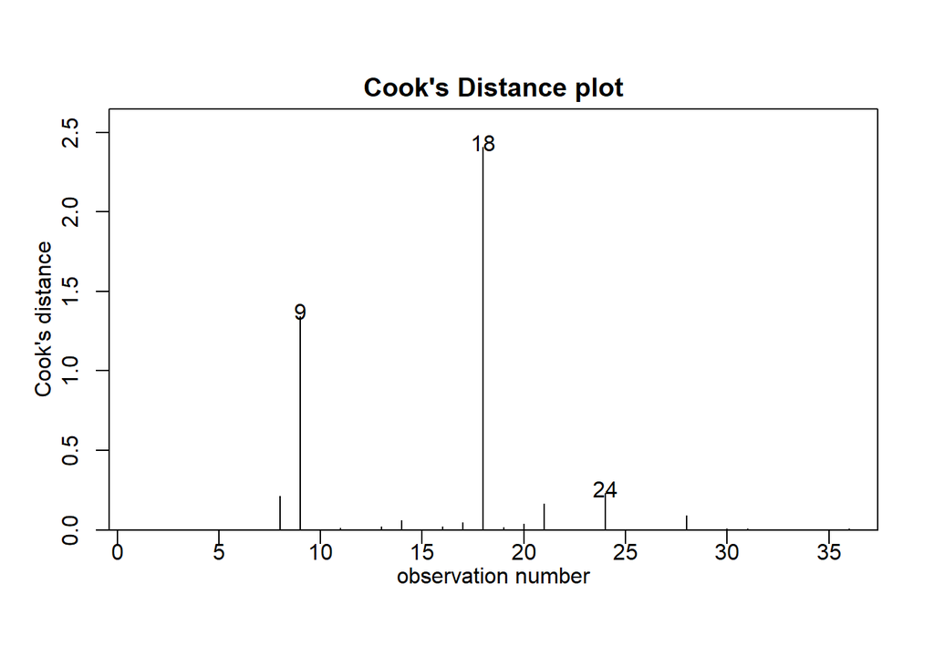

```r
  quad2.lm<-lm(BHDiameter~Height + I(BHDiameter^2),data=spruce[-18,])
  summary(quad2.lm)
```

```
##
## Call:
## lm(formula = BHDiameter ~ Height + I(BHDiameter^2), data = spruce[-18,
##     ])
##
## Residuals:
##      Min       1Q   Median       3Q      Max
## -1.56769 -0.15232  0.08743  0.35519  0.78944
##
## Coefficients:
##                  Estimate Std. Error t value Pr(>|t|)
## (Intercept)     6.0848180  0.9221330   6.599 1.94e-07 ***
## Height          0.2237083  0.0606665   3.688 0.000835 ***
## I(BHDiameter^2) 0.0231819  0.0008251  28.096  < 2e-16 ***
## ---
## Signif. codes:  0 '***' 0.001 '**' 0.01 '*' 0.05 '.' 0.1 ' ' 1
##
## Residual standard error: 0.5724 on 32 degrees of freedom
## Multiple R-squared:  0.9834, Adjusted R-squared:  0.9824
## F-statistic: 948.9 on 2 and 32 DF,  p-value: < 2.2e-16
```

```r
  summary(quad.lm)
```

```
##
## Call:
## lm(formula = BHDiameter ~ Height + I(BHDiameter^2), data = spruce)
##
## Residuals:
##     Min      1Q  Median      3Q     Max
## -1.6827 -0.1806  0.1122  0.3342  1.2596
##
## Coefficients:
##                  Estimate Std. Error t value Pr(>|t|)
## (Intercept)     3.8736362  0.8547565   4.532 7.28e-05 ***
## Height          0.3566159  0.0591578   6.028 8.88e-07 ***
## I(BHDiameter^2) 0.0224788  0.0009565  23.502  < 2e-16 ***
## ---
## Signif. codes:  0 '***' 0.001 '**' 0.01 '*' 0.05 '.' 0.1 ' ' 1
##
## Residual standard error: 0.6807 on 33 degrees of freedom
## Multiple R-squared:  0.9807, Adjusted R-squared:  0.9795
## F-statistic: 836.6 on 2 and 33 DF,  p-value: < 2.2e-16
```

A cooks plot shows the effect that a single observation has on the overall model, IE it helps detect outliers. The value of the bar is the effect that the observation has on the your confidence interval